# Scanner Data

[output not shown]

# Initial Objectives

### Checkout the `ICE CREAM` category

1. The `ICE CREAM` category will be used to explore the dataset and conduct exploratory data analysis.
2. The `ICE CREAM` category has four product module codes  
   (1) 2671: Yogurt - frozen  
   (2) 2672: Ice Cream - Bulk  
   (3) 2673: Ice Milk and Sherbet  
   (4) 2675: Frozen Novelties
3. Find the first date each product was introduced to the market  
   (q1) For each product per individual store or in general?
4. Find the value/amount difference among variables when a new product is introduced in the market  
   (q1) Variable selection?  
   (q2) Appropriate time frame?

### Handeling a large dataset

1. Compress the file into a binary format -> one tenth of the original .tsv file.
2. Memory is still an issue  
   (s1) Delete unnecessary variables  
   (s2) Change the type of variables in the dataset  
   (s3) Collapse the dataset. Is store_code_uce necessary?  
   (s4) Execute the script on the server

# Movement Files

### Data Structure

0. Ref. page 13 of the scanner manual
1. store_code_uce: A code used to identify the individual store. Physical location. Link scanner and panel data together.
2. upc: Universal Product Code (UPC) of a product
3. weekend: YYYMMDD format (Saturday)
4. unit: The number of units sold
5. prmult: The price multiplier
6. price: The avg. price of a product for that week
7. feature: ads
8. display: display
9. total_sale: Week’s total dollar sale. price/prmult*unit

### Initial Exploration of the Dataset

#### Toy Dataset

Store UC: 5593  
UPC: 7756702252  
Weekend Range: [2006-08-26, 2006-10-21]  
Number of Obs.: 3499  
Number of Unique UPC: 496

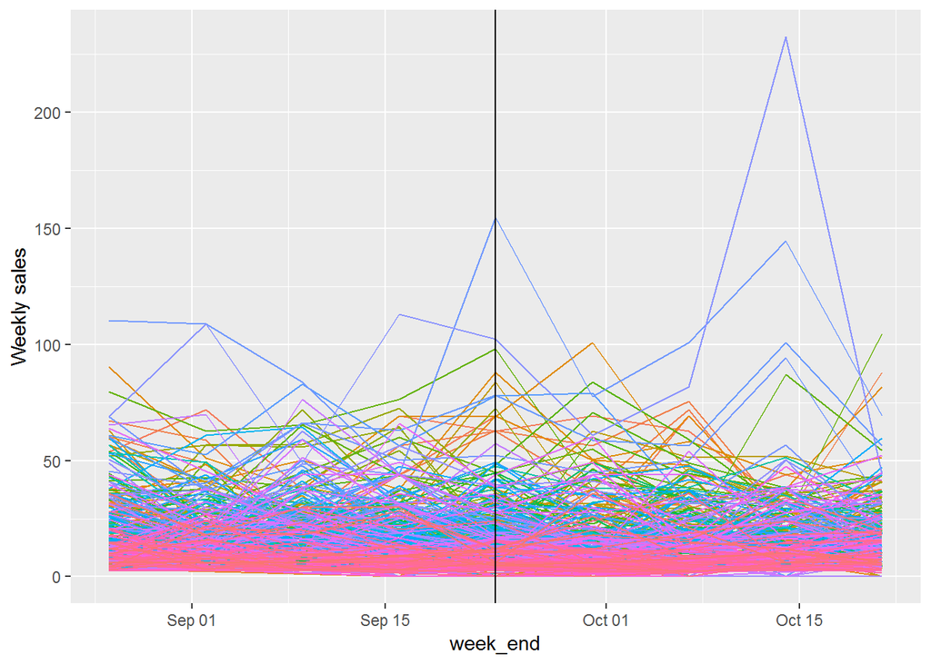

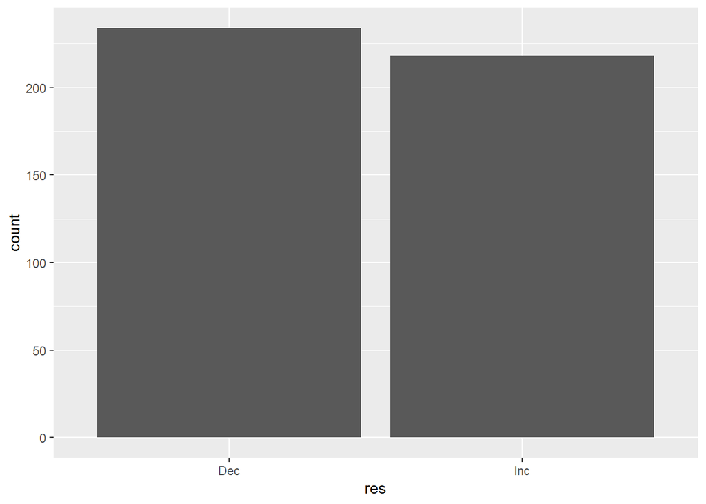